# Part II - Prosper Loans

## by Vicente Peña y Lillo

## Investigation Overview

The one of the main thoughts that people had at the moment of lending money is if they are going to paid back. So the main focus of this explanatory analysis is to determine wich features has relation with the risk of the borrowers.

For the reason explained before and after the exploratory analysis, were chosen the following figures:

- The distribution of the BorrowerRate, OnTimeRatio and EmploymentStatusDuration, and their relationship with the variable of interest ProsperScore.

  > Chosen because their condition of continous variables and commonly thought of clear relation with the borrower risk.
- The relationship between the EmploymentStatus and IncomeRange vs the variable of interest ProsperScore.

  > Chosen and arranged together because they relate to each other and showna clear relationship with the variable of interest.
- The highest and lowest states according to there borrowing rate.

  > Figure prooving that the occupation relate with the borrowing rate and the prosper score.

## Dataset Overview

The dataset contains 113,937 loans with 81 variables, including loan amount, borrower rate (or interest rate), current loan status, borrower income, and many others.

## Borrower Rate / On Time Payment Ratio / Employment Status Duration vs Prosper Score

The following figure show the distributions of the `BorrowerRate`, `OnTimeRatio` and `EmploymentStatusDuration`, and their relationship with the variable of interest `ProsperScore`.

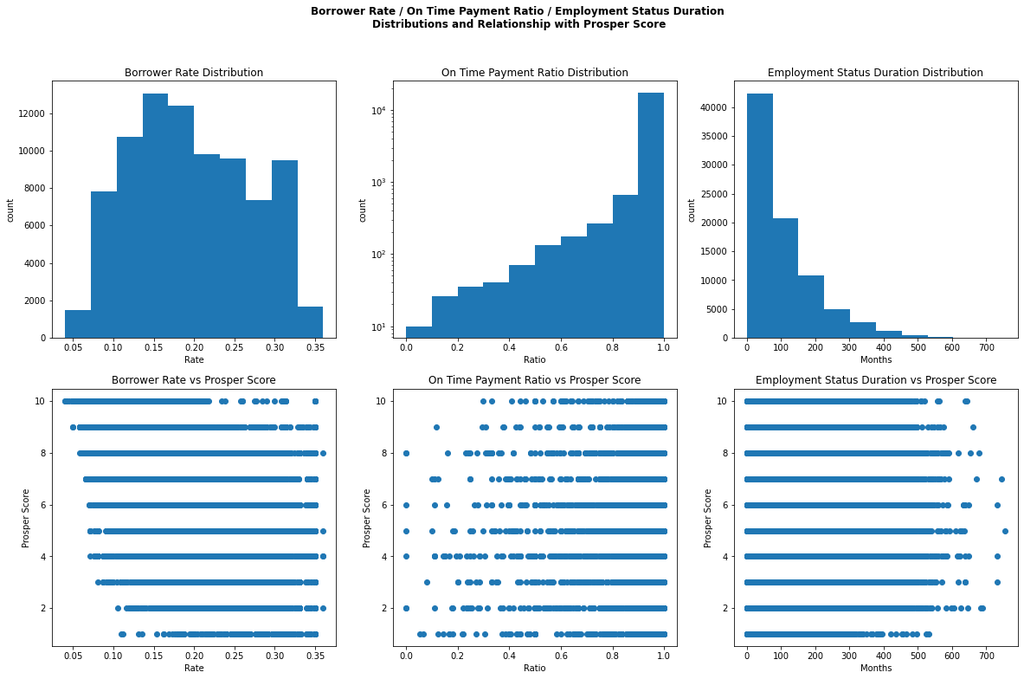

## Emplyment Status / Income Range vs Prosper Score

The following figure show the relationship between the `EmploymentStatus` and `IncomeRange` vs the variable of interest `ProsperScore`.

Implying the following:

- The **Full-time** and **Part-time** employees have a better `ProsperScore` than the not employed or self employed people.
- `IncomeRange` is positive correlated to `ProsperScore`.
- This features maybe related to each other being directly proportional the salary with the type of job.

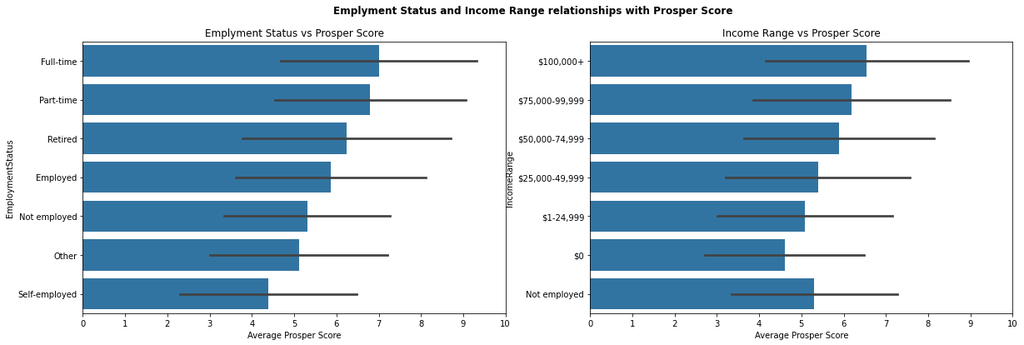

## Borrower State vs Borrower Rate

The following figure show the highest and lowest 5 states according to there borrowing rate.

Implying that the average borrowing rate deppends on the State, with highest rates for **AL** and the lowest for **DC**.

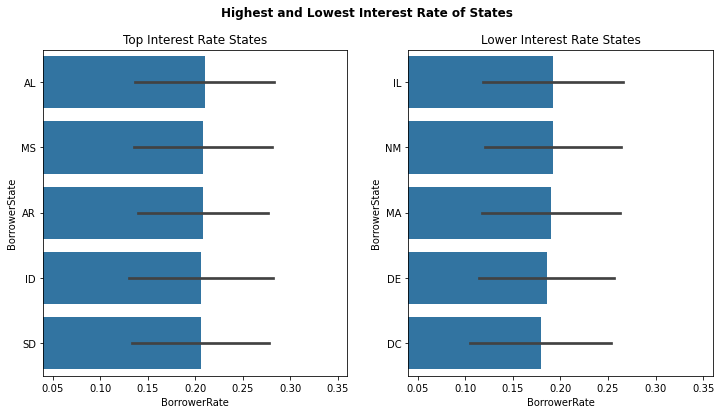

## Borrower Rate vs Prosper Score vs Occupations

The following figure show the 3 highest and lowest scored occupations correlated to `BorrowerRate` and `ProsperScore`.

Implying that there is a clear relationship between the `BorrowerRate`, `ProsperScore` and `Occupation`, where the `Occupation` is strengthed by the `BorrowerRate`.

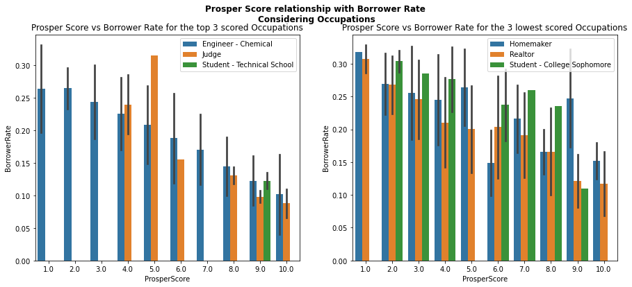